# US Open Men 2013 Analysis

April 16, 2017

#### **Business Understanding**

This is a public, multivariate dataset concerning the US Men’s Tennis Open in 2013. Our data is sourced from UCI Machine Learning Repository (Jauhari, Morankar, Fokoue)

> (https://archive.ics.uci.edu/ml/datasets/Tennis+Major+Tournament+Match+Statistics).

It has 42 variables in all. Each observation represents a singles tennis match.

The response variable which we will be attempting to predict will by FNL.1 (the final number of games won by player 1). In predicting this variable, some other variables become obsolete such as Result and STX.Y. Four other variables that we will not include in our analysis are WNR.X and UFE.X as no data populates those fields. Below is the complete list of variables and their uses.

| Use | Variable | Type | Description |
| --- | --- | --- | --- |
| None | Player 1 |  | Name of player 1 |
| None | Player 2 |  | Name of player 2 |
| None | Result | Ordinal (0/1) | Referenced on player 1. If player 1 wins- result=1 (FNL.1>FNL.2) |
| Covariate | FSP.1 | Real Number | First serve percentage for player 1 |
| Covariate | FSW.1 | Real Number | First serve won by player 1 |
| Covariate | SSP.1 | Real Number | Second serve percentage for player 1 |
| Covariate | SSW.1 | Real Number | Second serve won by player 1 |
| Covariate | ACE.1 | Numeric-Integer | Aces won by player 1 |
| Covariate | DBF.1 | Numeric-Integer | Double faults committed by player 1 |
| None | WNR.1 | Numeric | Winners earned by player 1 |
| None | UFE.1 | Numeric | Unforced errors committed by player 1 |
| Covariate | BPC.1 | Numeric | Break points created by player 1 |
| Covariate | BPW.1 | Numeric | Break points won by player 1 |
| Covariate | NPA.1 | Numeric | Net points attempted by player 1 |
| Covariate | NPW.1 | Numeric | Net points won by player 1 |
| Covariate | TPW.1 | Numeric | Total points won by player 1 |
| None | ST1.1 | Numeric-Integer | Set 1 Result for player 1 |
| None | ST2.1 | Numeric-Integer | Set 2 Result for player 1 |
| None | ST3.1 | Numeric-Integer | Set 3 Result for player 1 |
| None | ST4.1 | Numeric-Integer | Set 4 Result for player 1 |
| None | ST5.1 | Numeric-Integer | Set 5 Result for player 1 |
| Response | FNL.1 | Numeric-Integer | Final number of games won by player 1 |
| Covariate | FSP.1 | Real Number | First serve percentage for player 2 |
| Covariate | FSW.2 | Real Number | First serve won by player 2 |
| Covariate | SSP.2 | Real Number | Second servce percentage for player 2 |
| Covariate | SSW.2 | Real Number | Second serve won by player 2 |
| Covariate | ACE.2 | Numeric-Integer | Aces won by player 2 |
| Covariate | DBF.2 | Numeric-Integer | Double faults committed by player 2 |
| None | WNR.2 | Numeric | Winners earned by player 2 |
| None | UFE.2 | Numeric | Unforced errors committed by player 2 |
| Covariate | BPC.2 | Numeric | Break points created by player 2 |
| Covariate | BPW.2 | Numeric | Break points won by player 2 |
| Covariate | NPA.2 | Numeric | Net points attempted by player 2 |
| Covariate | NPW.2 | Numeric | Net points won by player 2 |
| Covariate | TPW.2 | Numeric | Total points won by player 2 |
| None | ST2.1 | Numeric-Integer | Set 1 Result for player 2 |
| None | ST2.2 | Numeric-Integer | Set 2 Result for player 2 |
| None | ST2.3 | Numeric-Integer | Set 3 Result for player 2 |
| None | ST2.4 | Numeric-Integer | Set 4 Result for player 2 |
| None | ST2.5 | Numeric-Integer | Set 5 Result for player 2 |
| None | FNL.2 | Numeric-Integer | Final number of games won by player 2 |
| Covariate | Round | Numeric-Integer | Round of the tournament at which the game is played |

#### **Data Understanding**

- We will use `dim` function to get the dimensions of the data
- `str` function to get the variable information
- `head` function to read first few observations
- `summary` function to get a summary of the data set

```r
usopen <- read.csv("USOpen-men-2013.csv")
dim(usopen)
```

```
## [1] 126  42
```

```r
str(usopen)
```

```
## 'data.frame':    126 obs. of  42 variables:
##  $ Player1: Factor w/ 81 levels "Adrian Mannarino",..: 65 74 37 7 26 47 10 60 24 54 ...
##  $ Player2: Factor w/ 79 levels "Adrian Mannarino",..: 52 2 30 17 23 9 18 35 5 6 ...
##  $ Round  : int  1 1 1 1 1 1 1 1 1 1 ...
##  $ Result : int  1 1 0 0 1 0 0 0 0 1 ...
##  $ FNL1   : int  3 3 2 1 3 1 2 1 2 3 ...
##  $ FNL2   : int  0 0 3 3 1 3 3 2 3 0 ...
##  $ FSP.1  : int  63 61 55 52 58 59 53 51 58 51 ...
##  $ FSW.1  : int  45 44 61 41 54 68 59 39 68 35 ...
##  $ SSP.1  : int  37 39 45 48 42 41 47 49 42 49 ...
##  $ SSW.1  : int  16 19 32 19 30 37 44 24 31 27 ...
##  $ ACE.1  : int  7 3 11 13 21 20 8 17 15 4 ...
##  $ DBF.1  : int  7 2 13 8 3 11 8 6 8 5 ...
##  $ WNR.1  : logi  NA NA NA NA NA NA ...
##  $ UFE.1  : logi  NA NA NA NA NA NA ...
```

[output cut: 28 more lines]

```r
head(usopen)
```

```
##              Player1         Player2 Round Result FNL1 FNL2 FSP.1 FSW.1
## 1    Richard Gasquet Michael Russell     1      1    3    0    63    45
## 2    Stephane Robert Albano Olivetti     1      1    3    0    61    44
## 3 Jan-Lennard Struff Guillaume Rufin     1      0    2    3    55    61
## 4       Aljaz Bedene Dmitry Tursunov     1      0    1    3    52    41
## 5    Feliciano Lopez   Florent Serra     1      1    3    1    58    54
## 6  Kenny De Schepper   Bradley Klahn     1      0    1    3    59    68
##   SSP.1 SSW.1 ACE.1 DBF.1 WNR.1 UFE.1 BPC.1 BPW.1 NPA.1 NPW.1 TPW.1 ST1.1
## 1    37    16     7     7    NA    NA     5    16    18    25   106     6
## 2    39    19     3     2    NA    NA     4    13    NA    NA    99     6
## 3    45    32    11    13    NA    NA     5    13    NA    NA   149     6
## 4    48    19    13     8    NA    NA     2     9    NA    NA    97     5
## 5    42    30    21     3    NA    NA     5    16    NA    NA   148     6
## 6    41    37    20    11    NA    NA     1     1    30    42   133     7
##   ST2.1 ST3.1 ST4.1 ST5.1 FSP.2 FSW.2 SSP.2 SSW.2 ACE.2 DBF.2 WNR.2 UFE.2
## 1     6     6    NA    NA    59    37    41    17     6     4    NA    NA
## 2     6     6    NA    NA    56    37    44    15    18     8    NA    NA
## 3     3     6     6     1    55    66    45    27    10     9    NA    NA
## 4     6     3     0    NA    55    52    45    27    16     3    NA    NA
## 5     6     6     6    NA    61    63    39    30     8     2    NA    NA
## 6     2     6     6    NA    71    72    29    26     6     1    NA    NA
##   BPC.2 BPW.2 NPA.2 NPW.2 TPW.2 ST1.2 ST2.2 ST3.2 ST4.2 ST5.2
## 1     1     3    30    40    83     3     4     2    NA    NA
## 2     0     1    NA    NA    71     3     3     4    NA    NA
## 3     5    15    NA    NA   149     7     6     2     2     6
## 4     6     9    NA    NA   121     7     4     6     6    NA
## 5     0     3    NA    NA   123     7     2     3     3    NA
## 6     3    11    30    48   151     6     6     7     7    NA
```

```r
summary(usopen)
```

```
##                Player1              Player2       Round       Result
##  Novak Djokovic    : 6   Rafael Nadal   : 7   Min.   :1   Min.   :0.0000
##  Richard Gasquet   : 6   David Ferrer   : 5   1st Qu.:1   1st Qu.:0.0000
##  Andy Murray       : 5   Mikhail Youzhny: 4   Median :1   Median :0.0000
##  Roger Federer     : 4   Milos Raonic   : 4   Mean   :1   Mean   :0.4683
##  Stanislas Wawrinka: 4   Tomas Berdych  : 4   3rd Qu.:1   3rd Qu.:1.0000
##  Tommy Robredo     : 4   Denis Istomin  : 3   Max.   :1   Max.   :1.0000
##  (Other)           :97   (Other)        :99
##       FNL1            FNL2           FSP.1           FSW.1
##  Min.   :0.000   Min.   :0.000   Min.   :38.00   Min.   :14.00
##  1st Qu.:1.000   1st Qu.:1.000   1st Qu.:53.00   1st Qu.:38.00
##  Median :2.000   Median :3.000   Median :59.00   Median :47.00
##  Mean   :1.841   Mean   :1.881   Mean   :58.65   Mean   :47.44
##  3rd Qu.:3.000   3rd Qu.:3.000   3rd Qu.:63.00   3rd Qu.:57.00
##  Max.   :3.000   Max.   :3.000   Max.   :75.00   Max.   :87.00
##
##      SSP.1           SSW.1           ACE.1            DBF.1
##  Min.   :25.00   Min.   : 8.00   Min.   : 0.000   Min.   : 0.000
##  1st Qu.:37.00   1st Qu.:17.00   1st Qu.: 5.000   1st Qu.: 3.000
##  Median :41.00   Median :23.00   Median : 8.000   Median : 5.000
##  Mean   :41.35   Mean   :23.38   Mean   : 8.508   Mean   : 4.952
##  3rd Qu.:47.00   3rd Qu.:29.00   3rd Qu.:11.000   3rd Qu.: 7.000
##  Max.   :62.00   Max.   :45.00   Max.   :29.000   Max.   :14.000
##
##   WNR.1          UFE.1             BPC.1            BPW.1
##  Mode:logical   Mode:logical   Min.   : 0.000   Min.   : 0.00
##  NA's:126       NA's:126       1st Qu.: 2.000   1st Qu.: 7.00
##                                Median : 5.000   Median :10.50
##                                Mean   : 4.198   Mean   :10.26
##                                3rd Qu.: 6.000   3rd Qu.:14.00
##                                Max.   :10.000   Max.   :23.00
##
##      NPA.1           NPW.1           TPW.1           ST1.1
##  Min.   : 4.00   Min.   : 4.00   Min.   : 38.0   Min.   :0.000
##  1st Qu.:12.00   1st Qu.:19.75   1st Qu.: 91.0   1st Qu.:4.000
##  Median :17.00   Median :25.50   Median :111.5   Median :6.000
##  Mean   :18.28   Mean   :27.86   Mean   :112.9   Mean   :4.968
##  3rd Qu.:25.00   3rd Qu.:36.25   3rd Qu.:137.0   3rd Qu.:6.000
##  Max.   :39.00   Max.   :63.00   Max.   :195.0   Max.   :7.000
##  NA's   :38      NA's   :38
```

[output cut: 33 more lines]

```
##  Min.   : 45.00   Min.   :0.000   Min.   :0.000   Min.   :0.000
##  1st Qu.: 87.25   1st Qu.:3.250   1st Qu.:3.000   1st Qu.:3.000
##  Median :114.00   Median :6.000   Median :6.000   Median :6.000
##  Mean   :113.18   Mean   :5.016   Mean   :4.516   Mean   :4.616
##  3rd Qu.:137.00   3rd Qu.:6.000   3rd Qu.:6.000   3rd Qu.:6.000
##  Max.   :207.00   Max.   :7.000   Max.   :7.000   Max.   :7.000
##                                                   NA's   :1
##      ST4.2           ST5.2
##  Min.   :0.000   Min.   :1.00
##  1st Qu.:4.000   1st Qu.:5.00
##  Median :6.000   Median :6.00
##  Mean   :5.015   Mean   :5.32
##  3rd Qu.:6.000   3rd Qu.:6.00
##  Max.   :7.000   Max.   :7.00
##  NA's   :59      NA's   :101
```

- Summary statistics
  - There are 126 observations with 42 varaibles
  - We read first few observations from the data set
  - WNR.1, WNR.2, UFE.2 and UFE.1 variables have no data
  - There are missing observations for ST4.1, ST5.1, NPA.2, NPW.2, ST3.2, ST4.2 and ST5.2 variables
- We use `hist` function to plot the histograms
- We use `plot` function to plot the density function
- As the varaibles are larger in number we avoid scatter plots at this moment

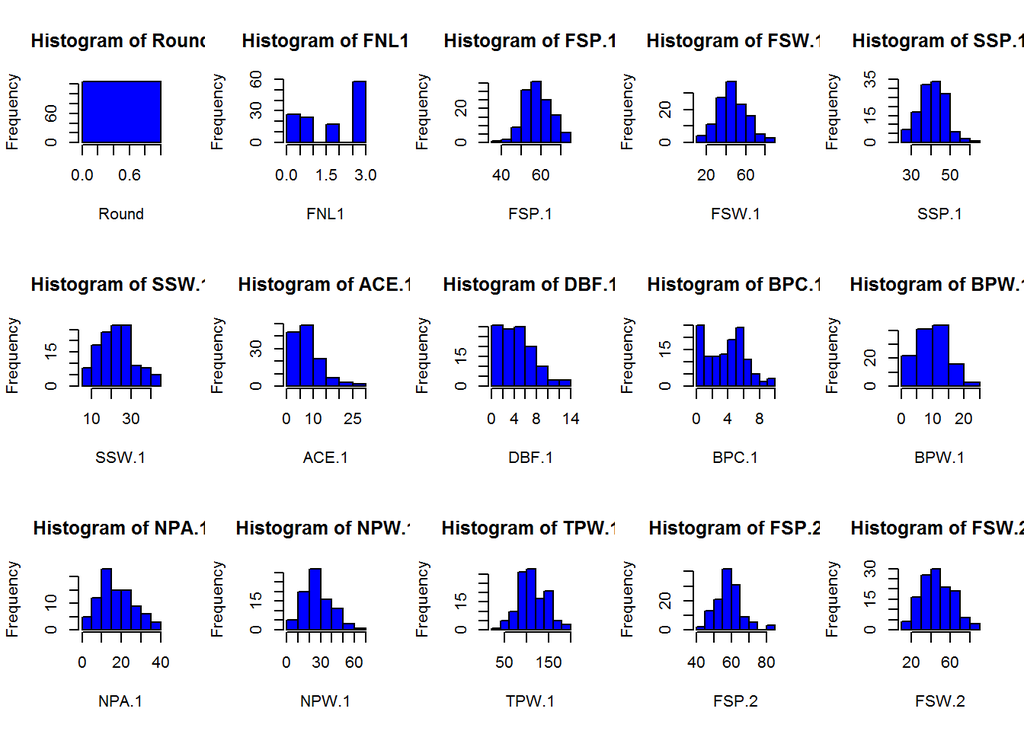

```r
#Histograms
par(mfrow=c(3,5))
hist(Round, col="blue",xlab="Round")
hist(FNL1, col="blue",xlab="FNL1")
hist(FSP.1, col="blue",xlab="FSP.1")
hist(FSW.1, col="blue",xlab="FSW.1")
hist(SSP.1, col="blue",xlab="SSP.1")
hist(SSW.1, col="blue",xlab="SSW.1")
hist(ACE.1, col="blue",xlab="ACE.1")
hist(DBF.1, col="blue",xlab="DBF.1")
hist(BPC.1, col="blue",xlab="BPC.1")
hist(BPW.1, col="blue",xlab="BPW.1")
hist(NPA.1, col="blue",xlab="NPA.1")
hist(NPW.1, col="blue",xlab="NPW.1")
hist(TPW.1, col="blue",xlab="TPW.1")
hist(FSP.2, col="blue",xlab="FSP.2")
hist(FSW.2, col="blue",xlab="FSW.2")
```

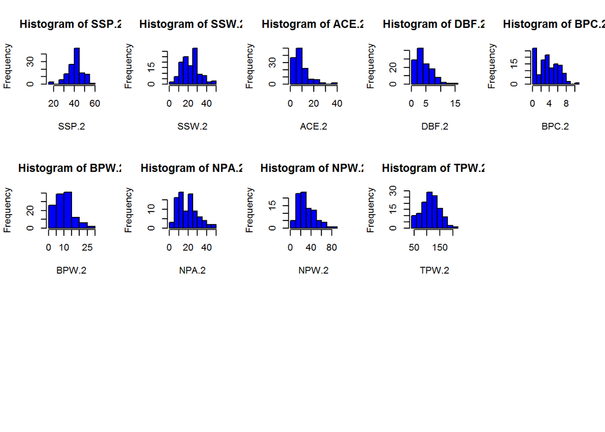

```r
par(mfrow=c(3,5))
hist(SSP.2, col="blue",xlab="SSP.2")
hist(SSW.2, col="blue",xlab="SSW.2")
hist(ACE.2, col="blue",xlab="ACE.2")
hist(DBF.2, col="blue",xlab="DBF.2")
hist(BPC.2, col="blue",xlab="BPC.2")
hist(BPW.2, col="blue",xlab="BPW.2")
hist(NPA.2, col="blue",xlab="NPA.2")
hist(NPW.2, col="blue",xlab="NPW.2")
hist(TPW.2, col="blue",xlab="TPW.2")

#Density Plot
par(mfrow=c(3,5))
```

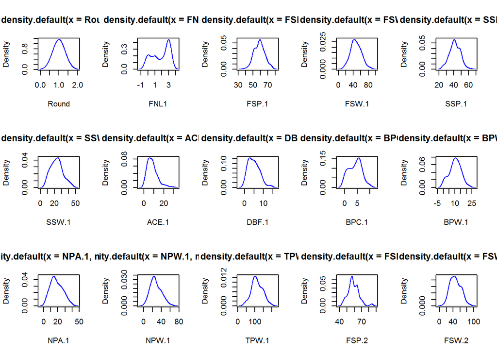

```r
plot(density(Round), col="blue",xlab="Round")
plot(density(FNL1), col="blue",xlab="FNL1")
plot(density(FSP.1), col="blue",xlab="FSP.1")
plot(density(FSW.1), col="blue",xlab="FSW.1")
plot(density(SSP.1), col="blue",xlab="SSP.1")
plot(density(SSW.1), col="blue",xlab="SSW.1")
plot(density(ACE.1), col="blue",xlab="ACE.1")
plot(density(DBF.1), col="blue",xlab="DBF.1")
plot(density(BPC.1), col="blue",xlab="BPC.1")
plot(density(BPW.1), col="blue",xlab="BPW.1")
plot(density(NPA.1,na.rm=T), col="blue",xlab="NPA.1")
plot(density(NPW.1,na.rm=T), col="blue",xlab="NPW.1")
plot(density(TPW.1), col="blue",xlab="TPW.1")
plot(density(FSP.2), col="blue",xlab="FSP.2")
plot(density(FSW.2), col="blue",xlab="FSW.2")
```

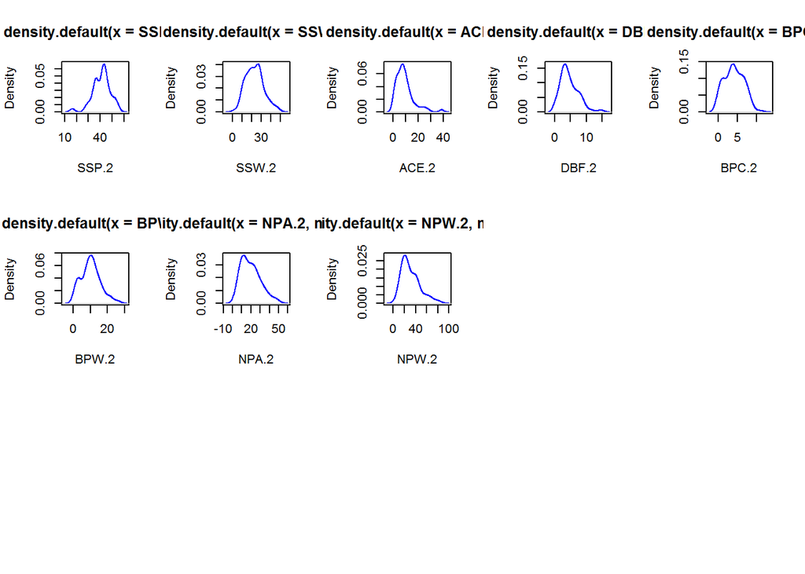

```r
par(mfrow=c(3,5))
plot(density(SSP.2), col="blue",xlab="SSP.2")
plot(density(SSW.2), col="blue",xlab="SSW.2")
plot(density(ACE.2), col="blue",xlab="ACE.2")
plot(density(DBF.2), col="blue",xlab="DBF.2")
plot(density(BPC.2), col="blue",xlab="BPC.2")
plot(density(BPW.2), col="blue",xlab="BPW.2")
plot(density(NPA.2,na.rm=T), col="blue",xlab="NPA.2")
plot(density(NPW.2,na.rm=T), col="blue",xlab="NPW.2")
```

- Most of the data is numeric with little or no cleaning required. We can replace the missing values with zero (or mean value) to simplify the data modeling process.

#### **Data Preparation**

```r
usopen$NPA.1[is.na(usopen$NPA.1)] <- 0
usopen$NPW.1[is.na(usopen$NPW.1)] <- 0
usopen$NPW.2[is.na(usopen$NPW.2)] <- 0
usopen$NPA.2[is.na(usopen$NPA.2)] <- 0
```

- Rest of the data looks pretty clean

#### **Modeling**

- We will utilize multiple linear regression method for this model.
- Based on the correlation matrix and partial f tests we will decide on the final list of covariates and final number of observations
- Correlation martix for the selected covariates

```r
cor(usopen[, c(
  "FSP.1",
  "FSW.1",
  "SSP.1",
  "SSW.1",
  "ACE.1",
  "DBF.1",
  "BPC.1",
  "BPW.1",
  "NPA.1",
  "NPW.1",
  "TPW.1",
  "FSP.2",
  "FSW.2",
  "SSP.2",
  "SSW.2",
  "ACE.2",
  "DBF.2",
  "BPC.2",
  "BPW.2",
  "NPA.2",
  "NPW.2",
  "TPW.2"
)])
```

```
##             FSP.1       FSW.1       SSP.1       SSW.1       ACE.1
## FSP.1  1.00000000  0.26459496 -1.00000000 -0.41593703 -0.01380294
## FSW.1  0.26459496  1.00000000 -0.26459496  0.64132808  0.42713326
## SSP.1 -1.00000000 -0.26459496  1.00000000  0.41593703  0.01380294
## SSW.1 -0.41593703  0.64132808  0.41593703  1.00000000  0.29906758
## ACE.1 -0.01380294  0.42713326  0.01380294  0.29906758  1.00000000
## DBF.1 -0.32465412  0.23723741  0.32465412  0.35399771  0.10858685
## BPC.1  0.05824994  0.19946459 -0.05824994  0.23373442  0.05301392
## BPW.1  0.07195850  0.42430857 -0.07195850  0.37078083  0.13728048
## NPA.1  0.16485854  0.33726153 -0.16485854  0.21942399  0.14740671
## NPW.1  0.14906540  0.30482782 -0.14906540  0.19334051  0.14142552
## TPW.1  0.01851359  0.88347991 -0.01851359  0.81021816  0.36557946
## FSP.2  0.09195440  0.06715300 -0.09195440 -0.04480885  0.14633471
## FSW.2 -0.02037330  0.82122320  0.02037330  0.68442458  0.36556976
## SSP.2 -0.09195440 -0.06715300  0.09195440  0.04480885 -0.14633471
## SSW.2 -0.16528489  0.60789937  0.16528489  0.65503373  0.18147835
## ACE.2 -0.05848740  0.43340157  0.05848740  0.40844326  0.01538041
## DBF.2 -0.06944526  0.30782657  0.06944526  0.38510617  0.01980387
## BPC.2 -0.31734117  0.02871383  0.31734117  0.15750967 -0.24778222
## BPW.2 -0.18498353  0.24867827  0.18498353  0.34320350 -0.20695525
## NPA.2  0.05963916  0.29090656 -0.05963916  0.25787637  0.05809668
## NPW.2  0.07536958  0.28560341 -0.07536958  0.26099024  0.06496308
## TPW.2 -0.15576924  0.77291241  0.15576924  0.75500731  0.20547247
##             DBF.1       BPC.1       BPW.1       NPA.1        NPW.1
## FSP.1 -0.32465412  0.05824994  0.07195850  0.16485854  0.149065402
## FSW.1  0.23723741  0.19946459  0.42430857  0.33726153  0.304827818
## SSP.1  0.32465412 -0.05824994 -0.07195850 -0.16485854 -0.149065402
## SSW.1  0.35399771  0.23373442  0.37078083  0.21942399  0.193340510
## ACE.1  0.10858685  0.05301392  0.13728048  0.14740671  0.141425517
## DBF.1  1.00000000 -0.05201502  0.09498148 -0.02402263 -0.041572916
## BPC.1 -0.05201502  1.00000000  0.72184636  0.12417091  0.077962292
## BPW.1  0.09498148  0.72184636  1.00000000  0.20968606  0.160420219
## NPA.1 -0.02402263  0.12417091  0.20968606  1.00000000  0.982373210
## NPW.1 -0.04157292  0.07796229  0.16042022  0.98237321  1.000000000
## TPW.1  0.26665322  0.46600563  0.68069589  0.31845748  0.278417950
## FSP.2 -0.03319813 -0.19842280 -0.21184871  0.34906276  0.373887092
## FSW.2  0.35127814 -0.06759904  0.28284139  0.36852073  0.363527892
## SSP.2  0.03319813  0.19842280  0.21184871 -0.34906276 -0.373887092
## SSW.2  0.29020489  0.04898860  0.37497838  0.03231227  0.007443394
## ACE.2  0.25850667 -0.13134799  0.09096564  0.12566790  0.112326715
```

[output cut: 60 more lines]

```
## BPW.1  0.15335862  0.299220648
## NPA.1  0.71238616  0.224106339
## NPW.1  0.70666119  0.219821897
## TPW.1  0.30216584  0.783115015
## FSP.2  0.24981364 -0.001022139
## FSW.2  0.32462790  0.881704144
## SSP.2 -0.24981364  0.001022139
## SSW.2  0.05821473  0.801675015
## ACE.2  0.16875319  0.470795346
## DBF.2  0.02765660  0.276641104
## BPC.2 -0.05467961  0.535544070
## BPW.2  0.03984518  0.601292789
## NPA.2  0.97605599  0.262926730
## NPW.2  1.00000000  0.211531222
## TPW.2  0.21153122  1.000000000
```

- We observe high correlation between NPA.1 and NPW.1, TPW.1 and FSW.1,NPA.2 and NPW.2, FSW.2 and TPW.2
- Other combinations of variables are also correlated
- There is a good probability that we may experience multicollinearity in our model
- We split the data set into testing (30%) and training data (70%)

```r
# setting the seed to make the partition reproductible
set.seed(999)
index <-
  sample(seq_len(nrow(usopen)), size = floor(0.70 * nrow(usopen)))

usopen_train <- usopen[index,]
usopen_test <- usopen[-index, ]
```

- We now create model based on training data
- `summary` function is used to get the model details

```r
model_usopen <-
  lm(
    FNL1 ~ FSP.1 + FSW.1 + SSP.1 + SSW.1 + ACE.1 + DBF.1 + BPC.1 + BPW.1 + NPA.1 +
      NPW.1 + TPW.1 + FSP.2 + FSW.2 + SSP.2 + SSW.2 + ACE.2 + DBF.2 + BPC.2 +
      BPW.2 + NPA.2 + NPW.2 + TPW.2,
    data = usopen_train
  )
summary(model_usopen)
```

```
##
## Call:
## lm(formula = FNL1 ~ FSP.1 + FSW.1 + SSP.1 + SSW.1 + ACE.1 + DBF.1 +
##     BPC.1 + BPW.1 + NPA.1 + NPW.1 + TPW.1 + FSP.2 + FSW.2 + SSP.2 +
##     SSW.2 + ACE.2 + DBF.2 + BPC.2 + BPW.2 + NPA.2 + NPW.2 + TPW.2,
##     data = usopen_train)
##
## Residuals:
##      Min       1Q   Median       3Q      Max
## -0.97603 -0.30841  0.03371  0.33374  1.05906
##
## Coefficients: (2 not defined because of singularities)
##              Estimate Std. Error t value Pr(>|t|)
## (Intercept) -1.262626   1.376240  -0.917  0.36220
## FSP.1        0.002551   0.015872   0.161  0.87280
## FSW.1       -0.002686   0.018716  -0.144  0.88630
## SSP.1              NA         NA      NA       NA
## SSW.1        0.007278   0.025829   0.282  0.77899
## ACE.1        0.005061   0.013210   0.383  0.70284
## DBF.1        0.024640   0.025376   0.971  0.33504
## BPC.1        0.116067   0.063603   1.825  0.07248 .
## BPW.1       -0.049449   0.026547  -1.863  0.06689 .
## NPA.1       -0.019090   0.030332  -0.629  0.53125
## NPW.1        0.007268   0.020210   0.360  0.72028
## TPW.1        0.061255   0.014343   4.271 6.29e-05 ***
## FSP.2        0.024471   0.015574   1.571  0.12083
## FSW.2       -0.009003   0.020432  -0.441  0.66090
## SSP.2              NA         NA      NA       NA
## SSW.2        0.027966   0.023308   1.200  0.23443
## ACE.2        0.021018   0.010839   1.939  0.05671 .
## DBF.2       -0.004163   0.029013  -0.143  0.88633
## BPC.2        0.086542   0.073086   1.184  0.24055
## BPW.2       -0.025209   0.026448  -0.953  0.34393
## NPA.2        0.041423   0.025749   1.609  0.11238
## NPW.2       -0.023605   0.017060  -1.384  0.17105
## TPW.2       -0.053608   0.016279  -3.293  0.00158 **
## ---
## Signif. codes:  0 '***' 0.001 '**' 0.01 '*' 0.05 '.' 0.1 ' ' 1
##
## Residual standard error: 0.4957 on 67 degrees of freedom
## Multiple R-squared:  0.8815, Adjusted R-squared:  0.8462
## F-statistic: 24.93 on 20 and 67 DF,  p-value: < 2.2e-16
```

- The null hypothesis is  
  $H_0: \beta_1=\beta_2=...=\beta_p=0$
- That is, there is not a single predictor which can be considered statistically significant
- The alternate hypothesis is  
  $H_a:$ At least one $\beta_j$ is not zero
- That is, there is at least predictor which can explain the change in resultant variable
- We reject null hypothesis when the p value is < 0.05
- From the model summary we observe that there are only 2 statisticallly significant variables (null hypothesis is rejected for these)
  - TPW.1
  - TPW.2
- The F-statistic is 24.93 and the corresponding p-value is significantly lower than 0.05 so we can conclude to reject that null hypothesis that no predictor varaible explains the variability in the response variable
- The $R^{2}$ value is 0.8815
- The model explains 88.15% of the varaibility in FNL1
- We now do a partial f-test for the variables FSP.1, FSW.1, SSP.1, SSW.1, ACE.1, DBF.1, NPA.1, NPW.1, FSP.2, FSW.2, SSP.2, SSW.2, ACE.2, DBF.2, NPA.2, NPW.2 and BPC.2

```r
model_usopen_p <-
  lm(FNL1 ~  BPC.1 + BPW.1 + TPW.1 + BPW.2 + TPW.2,
     data = usopen_train)
anova(model_usopen, model_usopen_p)
```

```
## Analysis of Variance Table
##
## Model 1: FNL1 ~ FSP.1 + FSW.1 + SSP.1 + SSW.1 + ACE.1 + DBF.1 + BPC.1 +
##     BPW.1 + NPA.1 + NPW.1 + TPW.1 + FSP.2 + FSW.2 + SSP.2 + SSW.2 +
##     ACE.2 + DBF.2 + BPC.2 + BPW.2 + NPA.2 + NPW.2 + TPW.2
## Model 2: FNL1 ~ BPC.1 + BPW.1 + TPW.1 + BPW.2 + TPW.2
##   Res.Df    RSS  Df Sum of Sq     F Pr(>F)
## 1     67 16.465
## 2     82 20.008 -15   -3.5425 0.961 0.5046
```

- We observe that p value is > 0.05 and therefore all these variables are not statistically significant
- We can now exclude these variables from our analysis
- We summarize our current model

```r
summary(model_usopen_p)
```

```
##
## Call:
## lm(formula = FNL1 ~ BPC.1 + BPW.1 + TPW.1 + BPW.2 + TPW.2, data = usopen_train)
##
## Residuals:
##      Min       1Q   Median       3Q      Max
## -0.94966 -0.29081  0.04009  0.31831  1.20486
##
## Coefficients:
##              Estimate Std. Error t value Pr(>|t|)
## (Intercept)  0.409225   0.201126   2.035  0.04512 *
## BPC.1        0.163649   0.043440   3.767  0.00031 ***
## BPW.1       -0.055868   0.017387  -3.213  0.00188 **
## TPW.1        0.048078   0.005446   8.828 1.58e-13 ***
## BPW.2       -0.024529   0.015967  -1.536  0.12834
## TPW.2       -0.034274   0.005362  -6.392 9.40e-09 ***
## ---
## Signif. codes:  0 '***' 0.001 '**' 0.01 '*' 0.05 '.' 0.1 ' ' 1
##
## Residual standard error: 0.494 on 82 degrees of freedom
## Multiple R-squared:  0.856,  Adjusted R-squared:  0.8473
## F-statistic: 97.53 on 5 and 82 DF,  p-value: < 2.2e-16
```

- We run another partial f-test for the variable BPW.2

```r
model_usopen_p_2 <-
  lm(FNL1 ~ BPC.1 +  BPW.1 + TPW.1 +  TPW.2,
     data = usopen_train)
anova(model_usopen_p, model_usopen_p_2)
```

```
## Analysis of Variance Table
##
## Model 1: FNL1 ~ BPC.1 + BPW.1 + TPW.1 + BPW.2 + TPW.2
## Model 2: FNL1 ~ BPC.1 + BPW.1 + TPW.1 + TPW.2
##   Res.Df    RSS Df Sum of Sq      F Pr(>F)
## 1     82 20.008
## 2     83 20.584 -1  -0.57582 2.3599 0.1283
```

- We again get a p-value > 0.05
- Hence BPW.2 is also not statistically significant
- We summarize our current model

```r
summary(model_usopen_p_2)
```

```
##
## Call:
## lm(formula = FNL1 ~ BPC.1 + BPW.1 + TPW.1 + TPW.2, data = usopen_train)
##
## Residuals:
##      Min       1Q   Median       3Q      Max
## -1.04081 -0.40456  0.08174  0.36555  1.07170
##
## Coefficients:
##              Estimate Std. Error t value Pr(>|t|)
## (Intercept)  0.397609   0.202623   1.962 0.053078 .
## BPC.1        0.132087   0.038586   3.423 0.000964 ***
## BPW.1       -0.053149   0.017437  -3.048 0.003090 **
## TPW.1        0.053237   0.004322  12.317  < 2e-16 ***
## TPW.2       -0.040555   0.003496 -11.599  < 2e-16 ***
## ---
## Signif. codes:  0 '***' 0.001 '**' 0.01 '*' 0.05 '.' 0.1 ' ' 1
##
## Residual standard error: 0.498 on 83 degrees of freedom
## Multiple R-squared:  0.8519, Adjusted R-squared:  0.8448
## F-statistic: 119.4 on 4 and 83 DF,  p-value: < 2.2e-16
```

- We now standardize the regression coefficients using unit normal scaling

```r
usopen_train_standard = as.data.frame(apply(usopen_train[, c("FNL1", "BPC.1", "BPW.1", "TPW.1", "TPW.2")], 2, function(x) {
  (x - mean(x)) / sd(x)
}))
```

- We now create the new model using standardized values

```r
model_usopen_std <-
  lm(FNL1 ~ BPC.1 +  BPW.1 + TPW.1 +  TPW.2,
     data = usopen_train_standard)
summary(model_usopen_std)
```

```
##
## Call:
## lm(formula = FNL1 ~ BPC.1 + BPW.1 + TPW.1 + TPW.2, data = usopen_train_standard)
##
## Residuals:
##      Min       1Q   Median       3Q      Max
## -0.82346 -0.32007  0.06467  0.28921  0.84790
##
## Coefficients:
##               Estimate Std. Error t value Pr(>|t|)
## (Intercept) -3.475e-16  4.200e-02   0.000 1.000000
## BPC.1        2.462e-01  7.192e-02   3.423 0.000964 ***
## BPW.1       -2.148e-01  7.047e-02  -3.048 0.003090 **
## TPW.1        1.426e+00  1.158e-01  12.317  < 2e-16 ***
## TPW.2       -1.125e+00  9.700e-02 -11.599  < 2e-16 ***
## ---
## Signif. codes:  0 '***' 0.001 '**' 0.01 '*' 0.05 '.' 0.1 ' ' 1
##
## Residual standard error: 0.394 on 83 degrees of freedom
## Multiple R-squared:  0.8519, Adjusted R-squared:  0.8448
## F-statistic: 119.4 on 4 and 83 DF,  p-value: < 2.2e-16
```

- To better visualize the coefficients we plot the `barplot`

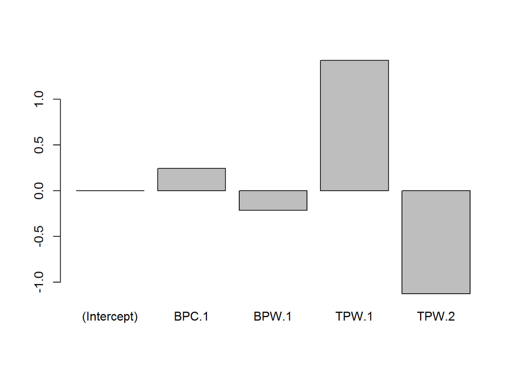

```r
barplot(model_usopen_std$coefficients)
```

- We observe that the most statistically significant variables are TPW.1 and TPW.2
- We check our model for multicolllinearity
- We will the `vif` function from `car` library to examine multicollinearity

```r
library(car)
vif(model_usopen_std)
```

```
##    BPC.1    BPW.1    TPW.1    TPW.2
## 2.899012 2.782959 7.514762 5.273466
```

- We observe that there is multicollinearity in our model (as was expected)
- We find the colleration matrix of the variables

```r
cor(usopen_train_standard[, c("FNL1",
                              "BPC.1",
                              "BPW.1",
                              "TPW.1",
                              "TPW.2")])
```

```
##              FNL1       BPC.1     BPW.1     TPW.1       TPW.2
## FNL1   1.00000000  0.75807021 0.5302779 0.4943759 -0.06581077
## BPC.1  0.75807021  1.00000000 0.6804967 0.4540390 -0.00928395
## BPW.1  0.53027788  0.68049669 1.0000000 0.6824489  0.35180657
## TPW.1  0.49437585  0.45403905 0.6824489 1.0000000  0.79731644
## TPW.2 -0.06581077 -0.00928395 0.3518066 0.7973164  1.00000000
```

#### **Evaluation**

- Multicollinearity is evident in this dataset as multiple covariates will impact each other by nature. For example, STX.Y will build up to FNL.X. As all observations are within the sphere of one match, most varibales will have some correlation to each other.
- We would also check for nonlinearity by comparing residual and fitted values
- Multicollinearity could be countered by collecting more data (not an option in this case as this is historical data), specifying the model differently (removing some covariates), or using Ridge Regression
- We plan on analyzing the residual plots and then select a fitting transformation for a better model